# Évolution de la date théorique de récolte

- Montrer tout le code
- Cacher tout le code
- Voir les sources

Agronomie et données climatiques rétrospectives avec ERA5

Michaël Delorme

2 juin 2023

Les organismes, dont les plantes, ont besoin d’une certaine quantité de chaleur pour se développer. La notion de *degrés jours* a été introduite par les biologistes pour quantifier ce besoin physiologique. Il s’exprime par la somme des différences entre la température moyenne journalière et une température de base[^1].

Le maïs a une température de base de 6 °C et il lui faut 1500 DJ (variable selon la précocité de la variété) pour être récolté pour l’ensilage[^2] destiné à nourrir le bétail, ou 1700 DJ pour le maïs grain. Les températures supérieures à 30 °C stoppent le développement végétatif. Le semis se fait début avril[^3].

**Peut-on voir comment a évolué la date de récolte théorique d’une parcelle de maïs au cours des dernières années ?**

# 1 Données

# 2 Préparation

Il faut avoir préalablement copié les données depuis le stockage S3 Minio :

`$ mc cp -r s3/projet-funathon/2023/sujet2/era5/ funathon2023_sujet2/donnees/era5/`

**voir le code**

```r
if (!"ag5Tools" %in% installed.packages()) { install.packages("ag5Tools") }
if (!"gtsummary" %in% installed.packages()) { install.packages("gtsummary") }

library(ag5Tools)
library(tidyverse)
library(glue)
library(fs)
library(knitr)
library(gtsummary)

# localisation des données dans le stockage "local"
rep_era5 <- "../donnees/era5"
rep_era5_full <- glue(path_real(rep_era5), "/")

invisible(Sys.setlocale("LC_ALL", "fr_FR.UTF-8"))
```

# 3 Extraction

**voir le code**

```r
# un exemple de localisations avec date début-fin
points <- tribble(~ville,       ~lon,   ~lat,
                  "Talissieu", 5.725, 45.864,
                  "Toulouse",  1.434, 43.591) %>%
  mutate(id = row_number(),
         start_date = "1979-01-01",
         end_date   = "2022-12-31")

# Extraction des températures moyennes journalières à ces points
temp_points <- points %>%
  as.data.frame() %>%
  ag5_extract(variable = "Temperature-Air-2m",
              statistic = "Mean-24h",
              celsius = TRUE,
              path = rep_era5_full) %>%
  imap(~ pivot_longer(.x,
                      everything(),
                      names_to = "date",
                      values_to = "temp_moy_c",
                      names_transform = ymd) %>%
         mutate(id = .y)) %>%
  bind_rows() %>%
  inner_join(points, by = "id")
```

# 4 Calcul des degrés jour et des dates de récolte

**voir le code**

```r
# la date n'est pas un bon indicateur pour suivre précisémment une évolution
# journalière à cause des années bissextiles
#   -> on utilisaera le day of year (doy)
# yday(ymd("2020-04-01"))
# yday(ymd("2023-04-01"))

# base de calcul pour maïs : 6 °C
base <- 6 # °C

# besoin total à récolte pour un maïs grain de précocité moyenne : 1700 DJ
besoin <- 1700 # DJ

recolte <- temp_points %>%
  select(date, id, ville, temp_moy_c) %>%
  group_by(ville, annee = year(date)) %>%
  mutate(dj = case_when(yday(date) < 91 ~ 0,
                        temp_moy_c > 30 ~ 0,
                        temp_moy_c < base ~ 0,
                        TRUE ~ temp_moy_c - base),
         sdj = cumsum(dj)) %>%
  filter(sdj > besoin) %>%
  slice_min(date) %>%
  ungroup() %>%
  select(date, annee, id, ville)
```

Tableau 1 – Dates de récolte potentielles

| date | annee | id | ville |
| --- | --- | --- | --- |
| 1983-10-13 | 1983 | 1 | Talissieu |
| 1986-11-12 | 1986 | 1 | Talissieu |
| 1987-12-17 | 1987 | 1 | Talissieu |
| 1988-10-27 | 1988 | 1 | Talissieu |
| 1989-10-26 | 1989 | 1 | Talissieu |
| 1990-10-24 | 1990 | 1 | Talissieu |
| 1992-10-27 | 1992 | 1 | Talissieu |
| 1994-10-05 | 1994 | 1 | Talissieu |
| 1995-10-31 | 1995 | 1 | Talissieu |
| 1997-10-11 | 1997 | 1 | Talissieu |
| 1998-10-27 | 1998 | 1 | Talissieu |
| 1999-10-02 | 1999 | 1 | Talissieu |
| 2000-10-14 | 2000 | 1 | Talissieu |
| 2001-10-19 | 2001 | 1 | Talissieu |
| 2002-11-25 | 2002 | 1 | Talissieu |
| 2003-08-28 | 2003 | 1 | Talissieu |
| 2004-10-12 | 2004 | 1 | Talissieu |
| 2005-10-05 | 2005 | 1 | Talissieu |
| 2006-09-23 | 2006 | 1 | Talissieu |
| 2007-10-06 | 2007 | 1 | Talissieu |
| 2008-11-03 | 2008 | 1 | Talissieu |
| 2009-09-16 | 2009 | 1 | Talissieu |
| 2010-10-10 | 2010 | 1 | Talissieu |
| 2011-09-24 | 2011 | 1 | Talissieu |
| 2012-10-02 | 2012 | 1 | Talissieu |
| 2013-10-21 | 2013 | 1 | Talissieu |
| 2014-10-13 | 2014 | 1 | Talissieu |
| 2015-09-10 | 2015 | 1 | Talissieu |
| 2016-10-02 | 2016 | 1 | Talissieu |
| 2017-09-25 | 2017 | 1 | Talissieu |
| 2018-09-05 | 2018 | 1 | Talissieu |
| 2019-09-22 | 2019 | 1 | Talissieu |
| 2020-09-13 | 2020 | 1 | Talissieu |
| 2021-10-29 | 2021 | 1 | Talissieu |
| 2022-08-29 | 2022 | 1 | Talissieu |
| 1979-09-10 | 1979 | 2 | Toulouse |
| 1980-09-18 | 1980 | 2 | Toulouse |
| 1981-09-05 | 1981 | 2 | Toulouse |
| 1982-08-26 | 1982 | 2 | Toulouse |
| 1983-08-25 | 1983 | 2 | Toulouse |
| 1984-09-09 | 1984 | 2 | Toulouse |
| 1985-09-03 | 1985 | 2 | Toulouse |
| 1986-09-03 | 1986 | 2 | Toulouse |
| 1987-08-31 | 1987 | 2 | Toulouse |
| 1988-08-28 | 1988 | 2 | Toulouse |
| 1989-08-18 | 1989 | 2 | Toulouse |
| 1990-08-20 | 1990 | 2 | Toulouse |
| 1991-09-02 | 1991 | 2 | Toulouse |
| 1992-08-30 | 1992 | 2 | Toulouse |
| 1993-08-30 | 1993 | 2 | Toulouse |
| 1994-08-23 | 1994 | 2 | Toulouse |
| 1995-08-23 | 1995 | 2 | Toulouse |
| 1996-08-25 | 1996 | 2 | Toulouse |
| 1997-08-20 | 1997 | 2 | Toulouse |
| 1998-08-24 | 1998 | 2 | Toulouse |
| 1999-08-22 | 1999 | 2 | Toulouse |
| 2000-08-23 | 2000 | 2 | Toulouse |
| 2001-08-26 | 2001 | 2 | Toulouse |
| 2002-08-31 | 2002 | 2 | Toulouse |
| 2003-08-08 | 2003 | 2 | Toulouse |
| 2004-08-21 | 2004 | 2 | Toulouse |
| 2005-08-16 | 2005 | 2 | Toulouse |
| 2006-08-10 | 2006 | 2 | Toulouse |
| 2007-08-23 | 2007 | 2 | Toulouse |
| 2008-08-26 | 2008 | 2 | Toulouse |
| 2009-08-16 | 2009 | 2 | Toulouse |
| 2010-08-19 | 2010 | 2 | Toulouse |
| 2011-08-14 | 2011 | 2 | Toulouse |
| 2012-08-15 | 2012 | 2 | Toulouse |
| 2013-08-27 | 2013 | 2 | Toulouse |
| 2014-08-25 | 2014 | 2 | Toulouse |
| 2015-08-10 | 2015 | 2 | Toulouse |
| 2016-08-20 | 2016 | 2 | Toulouse |
| 2017-08-12 | 2017 | 2 | Toulouse |
| 2018-08-13 | 2018 | 2 | Toulouse |
| 2019-08-18 | 2019 | 2 | Toulouse |
| 2020-08-09 | 2020 | 2 | Toulouse |
| 2021-08-23 | 2021 | 2 | Toulouse |
| 2022-08-03 | 2022 | 2 | Toulouse |

# 5 Visualisation

**voir le code**

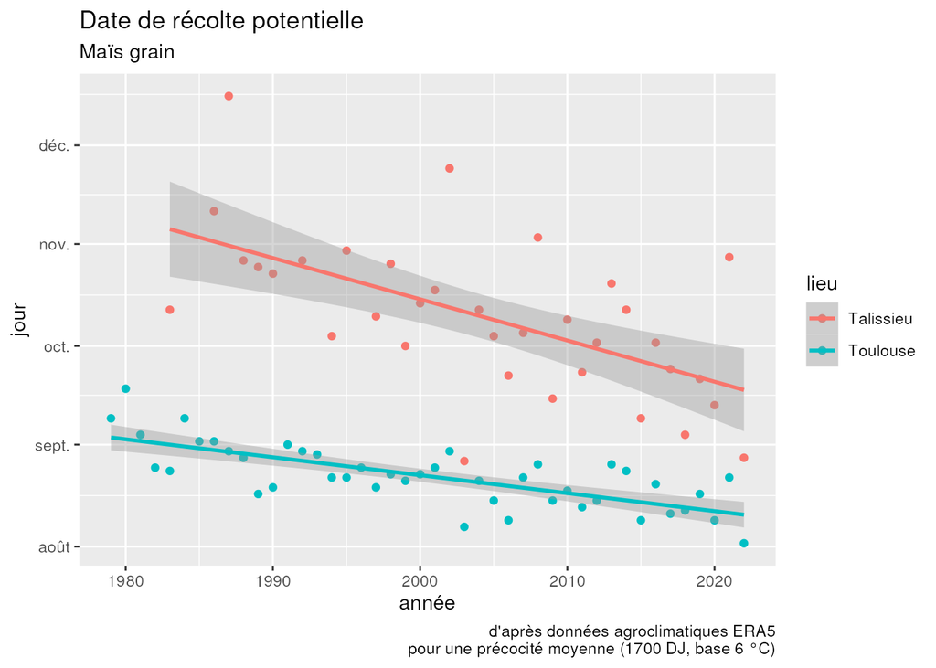

Figure 1 – Évolution de la date de récolte potentielle du maïs grain

```r
recolte %>%
  mutate(doy = yday(date),
         date_virtuelle = as_date(parse_date_time(glue("2020-{str_pad(doy, 3, 'left', '0')}"),
                                                  orders = "yj"))) %>%
  ggplot(aes(annee, date_virtuelle, color = ville)) +
  geom_point() +
  geom_smooth(method = lm) +
  scale_y_date(date_breaks = "months", date_labels = "%b") +
  labs(title = "Date de récolte potentielle",
       subtitle = "Maïs grain",
       x = "année",
       y = "jour",
       color = "lieu",
       caption = glue("d'après données agroclimatiques ERA5
                       pour une précocité moyenne ({besoin} DJ, base {base} °C)"))
```

# 6 Tendance

**voir le code**

```r
mod <- recolte %>%
  mutate(doy = yday(date)) %>%
  glm(doy ~ annee + ville, data = .)

tbl_regression(mod)
```

| **Characteristic** | **Beta** | **95% CI**<sup>1</sup> | **p-value** |
| --- | --- | --- | --- |
| annee | -0.81 | -1.1, -0.55 | <0.001 |
| ville |  |  |  |
| Talissieu | — | — |  |
| Toulouse | -51 | -58, -45 | <0.001 |

<sup>1</sup> CI = Confidence Interval

## Notes de bas de page

[^1]: [Degré jour de croissance. *Wikipedia*](https://fr.wikipedia.org/wiki/Degr%C3%A9_jour_de_croissance)
[^2]: [*Spotifarm*](https://blog.spotifarm.fr/tour-de-plaine-spotifarm/somme-de-temperature-pourquoi-suivre-levolution-des-degres-jours)
[^3]: [Céré’Obs. *FranceAgrimer*](https://cereobs.franceagrimer.fr/cereobs-sp/assets/pdfjs/web/viewer.html?file=blob:https://cereobs.franceagrimer.fr/f05c19c6-aff4-4701-9af4-80fdef7118d3)